# GroupTrack — User Manual

Version 2.7c · One Map · draft of 26 October 2026

**Two documents, two jobs.** The **Quick Start** (MENU › Help › Quick Start) shows you how to use GroupTrack's tools together — how to get around One Map and accomplish what you set out to do as a rider: plan a ride, get the maps, ride it, ride with a group. **Start there.** This **manual** is the reference for each process: what every button and screen does, step by step. HELP on any panel opens it at that process.

**What GroupTrack is.** A trail app for off-road riders — side-by-side, UTV, ATV, dirt bike and Jeep — complete as installed. It is two products in one: a complete personal navigation app that lets you share rides and maps with other GroupTrack users, and true situational awareness for your group on the trail. The trails and the maps live on your tablet, so it keeps working where there is no signal — which is most of where you ride.

**You do not have to take it all on at once.** Most riders never go past the second step, and that is a complete and useful app.

1. **Ride and record.** Trails on your tablet, maps that work with no signal, and a record of where you went.
2. **Plan before you go.** Download the maps you will need, bring in what you have from Gaia or onX (GPX), and build the route — draw it yourself, or let the AI planner build several and compare them.
3. **Ride as a group.** See where everyone is, with no cell service. An organizer builds a ride and sends it; each rider opens it with one tap, checks in at the trailhead and takes a role. A rider does not even need a tablet: the radio reports its position by itself, so a radio round the neck puts a rider on everyone's map.

**Accepting a ride invitation goes like this:** tap the ride attachment in your email invitation, then watch as the route, the trailhead, the offline maps and the mesh radio setup for the ride are created on your tablet. With a radio, check in at the trailhead; then ride. For the organizer it is one step: build the ride and send it.

Carried from the 2.7b manual (1.1, 1.3).

### The map, lettered — tap a line to open that section

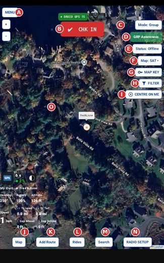

**The standard header**

Every panel has the same header. **HELP** opens this manual at the function you are in. **ISSUE** captures the screen and sends it to us by email — please say in the email what went wrong. **✕** closes the panel.

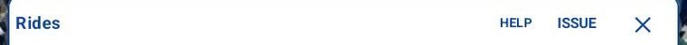

HELP, ISSUE, ✕ on every panel

**Colours that follow the map**

Panels and buttons follow the map you are looking at, so they stay readable against it: on the satellite map they are white with blue writing; on TOPO and TOPO+ they are blue with white writing. A box always has the opposite colours to its panel.

**On the SAT map**  
Blue writing on white

A choice in a box

**On TOPO and TOPO+**  
White writing on blue

A choice in a box

**Impact of Android only mode**

**Android only** is one rider with no radio: the tablet's own GPS places your cart. **Group** is several riders, each with a mesh radio: the map shows every cart in the group. The **Mode** button (C) switches GroupTrack between them, and the screen changes with it — Android only on the left, Group on the right:

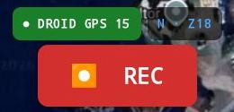

Android only: REC

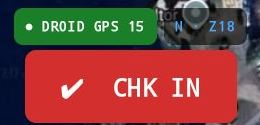

Group: CHK IN

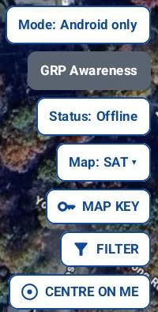

Android only: GRP Awareness grey

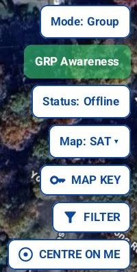

Group: GRP Awareness green when your radio talks

[figure not shown]

Android only: four buttons

[figure not shown]

**The GPS lamp, the zoom level and the readout**

**The GPS lamp** at the top says whose GPS places your cart and how many satellites it sees (**DROID GPS 15** = the tablet's own GPS with 15 satellites). Beside it, **N · Z18**: **N** means north is at the top (the map does not turn), and **Z** is the zoom level — **Z1** shows the whole world and **Z18** is the closest GroupTrack shows maps for. Each step in zoom halves the distance shown:

| Zoom | One map tile covers about |
| --- | --- |
| Z18 (closest) | 380 ft square — a few houses |
| Z16 | 1,500 ft — a neighbourhood |
| Z14 | 1.2 miles — a trail system |
| Z12 | 4.6 miles — a riding area |
| Z1 | the whole world |

Distances at the latitude of Utah and New Hampshire (about 40°). A tablet screen shows several tiles across.

**The readout** at the bottom left shows your cart — heading, battery, altitude, speed, and the distance to the lead and the tail.

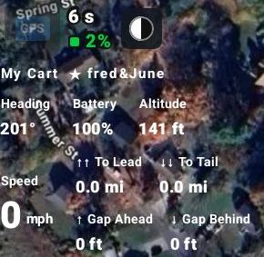

The readout — MY CART

**Before the map: first start, and opening a ride you were sent**

**A · MENU — settings, help and your account**

What is it?

MENU, top left, holds the things you set once and the documents that come with GroupTrack: **Settings**, **Help** and **Account**.

How do I use it?

Tap **MENU**, then the line you want. ✕ closes it.

[figure not shown]

Menu screen one map

What does it mean to me?

Everything that is not part of riding is in one place, out of the way of the map.

**Account — your rider profile**

What is it?

Your rider profile: who you are in GroupTrack. Required now — your email is used when you send a ride or a report — and it becomes your GroupTrack account in version 3.0.

How do I use it?

MENU › **Account** (or Settings › Edit rider profile):

- **First and last name.**
- **Callsign** (required) — shown to your group on the map and in every message your radio sends. Two riders may share one; the radios tell you apart.
- **Email** (required) — used when you send a ride file or share a ride. **Cell** is optional.
- **How you usually ride** — your default role (Leader, Rider, Middle, Tail gunner), your vehicle and your team colour on the map. These are defaults: you can change them on any ride.

Changes are kept as you make them; ✕ closes.

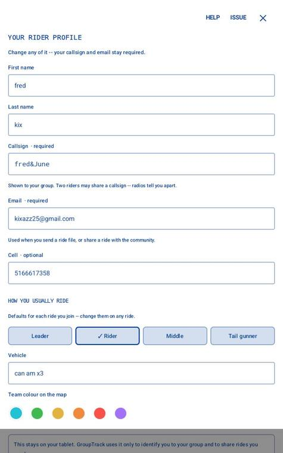

Account

What does it mean to me?

Your group sees who you are, and rides you send carry your name. It stays on your tablet: GroupTrack uses it only to identify you to your group and to share rides you choose to send.

**More: Why GroupTrack asks for your profile**

The first time you open GroupTrack it asks for your name, a callsign and an email address — once. GroupTrack uses standard TAK messaging to put your group on each other's maps: that needs a name beside your cart, and an email so you can send ride details to the riders coming with you.

**Your callsign** is what everyone sees — on the map, and in every message your radio sends. Short and recognisable works best. Two riders can share a callsign; the radios still tell you apart.

**It stays on your tablet.** Nothing is sent to GroupTrack. Your details go only to the riders you ride with, over the radio, or in ride files you choose to send.

**Changing it later.** Everything is editable, though the callsign and email stay required. The rest are your defaults for each ride: your usual role, your vehicle and your colour on the map. Your default role is the one offered when you check in — most riders leave it as Rider; on a ride you created, Leader is offered. At check-in you can change your role and callsign for that ride only.

Carried from the 2.7b manual — check the wording.

**Help — Quick Start, Release Notes, User Manual**

What is it?

The three documents that come with GroupTrack. **Quick Start** — the short version: set up and go, the common jobs step by step. **Release Notes** — what changed, newest first. **Full Manual** — this manual: every process, in detail.

How do I use it?

MENU › **Help**, then the document. It opens on top of the map; ✕ returns you to the map. HELP on any panel opens this manual at that panel's process.

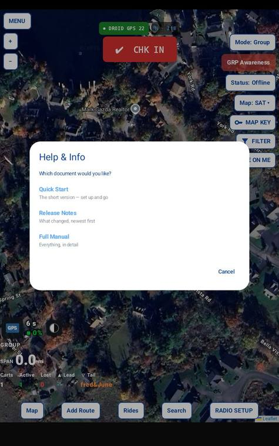

Help and info panel

What does it mean to me?

Start with the Quick Start; come here when you want the detail of one process.

**Release Notes**

What is it?

What is new in this version, newest first; earlier releases are folded.

How do I use it?

MENU › Help › **Release Notes**. Tap an earlier release to open it.

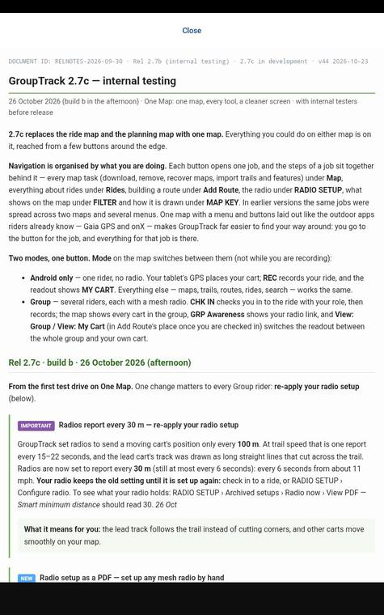

New release

What does it mean to me?

After an update you know what changed and what to do.

**Quick Start**

What is it?

How to use GroupTrack's tools together for the common jobs — set up, plan, get the maps, ride, ride with a group.

How do I use it?

MENU › Help › **Quick Start**. Each job links to the manual sections it uses.

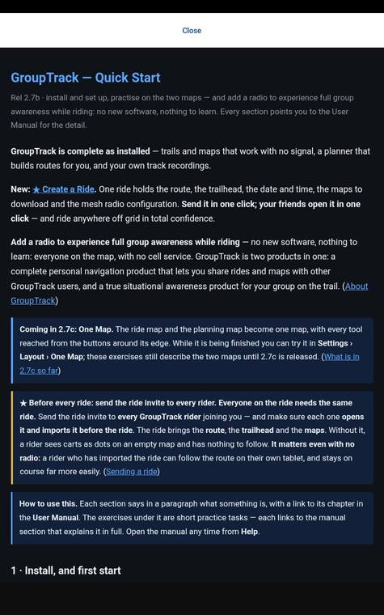

Quick Start

What does it mean to me?

The fastest way to be riding.

**User Manual**

What is it?

This manual.

How do I use it?

MENU › Help › **Full Manual**, or HELP on any panel.

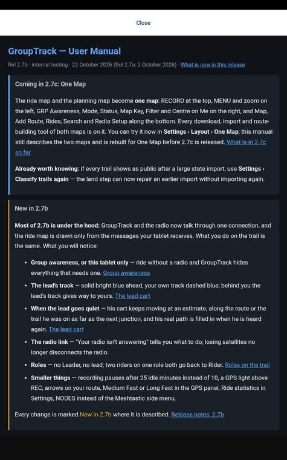

User manual

What does it mean to me?

The detail of every process, one tap from where you are.

**Settings**

What is it?

The settings for this tablet: storage, trail data, your profile, map sources, issue reports and group awareness. With group awareness on, the group settings appear too.

How do I use it?

MENU › **Settings**. A switch changes its setting at once; a line with a description under it opens its own screen. The screens below show what to tap.

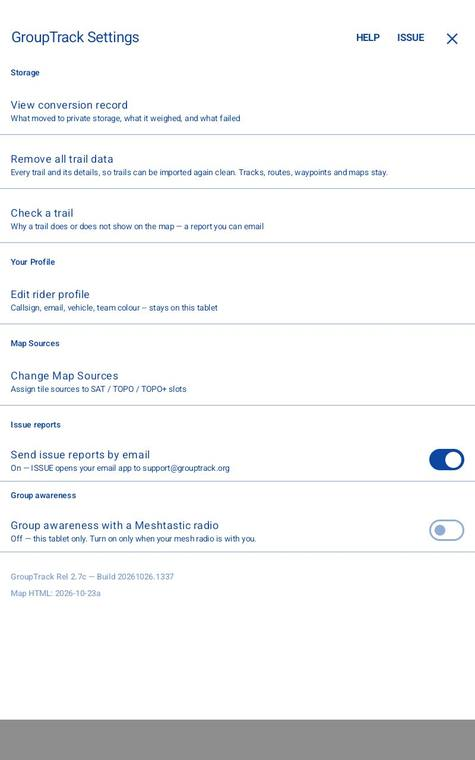

Settings with group awareness off

**Settings, riding with the tablet only.** Tap a line to open it:

- **To find out why a trail is missing:** Check a trail (open the map on the spot first).
- **To start your trails again cleanly:** Remove all trail data — then import them again (Map, J).
- **To change your callsign, email, vehicle or colour:** Edit rider profile.
- **To change which maps SAT, TOPO and TOPO+ use:** Change Map Sources.
- **To keep issue reports on the tablet instead of emailing them:** turn **Send issue reports by email** off.
- **Riding with a mesh radio:** turn **Group awareness with a Meshtastic radio** on — the group settings appear (next screen).

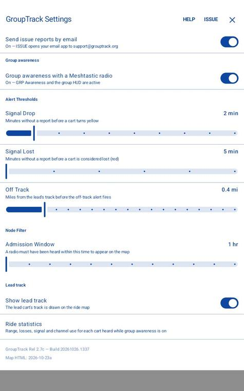

Additional setting with group awareness on

**With group awareness on.** Drag a slider to change its value; the value shows on the right.

- **To be warned sooner, or later, when a cart goes quiet:** **Signal Drop** (it turns yellow; 2 min) and **Signal Lost** (red; 5 min).
- **To change when a cart counts as off the leader's track:** **Off Track** (0.4 mi).
- **To hide radios that have not been heard recently:** **Admission Window** — a radio must have been heard within this time to appear on the map (1 hr).
- **To show or hide the leader's path:** **Show lead track**.
- **To see how well the radios heard each other:** Ride statistics.

What does it mean to me?

You can tune GroupTrack to how you ride — and turn group awareness on only when your radio is with you.

**Change Map Sources**

What is it?

The same screens as Map › Map source.

How do I use it?

See Map source.

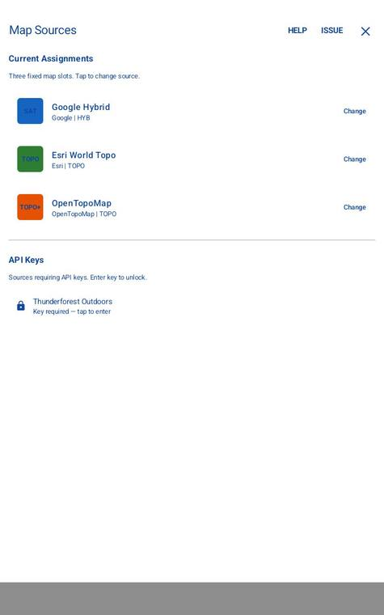

Change map source screen 1

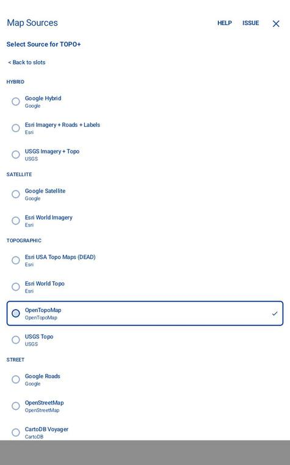

Change map source screen 2

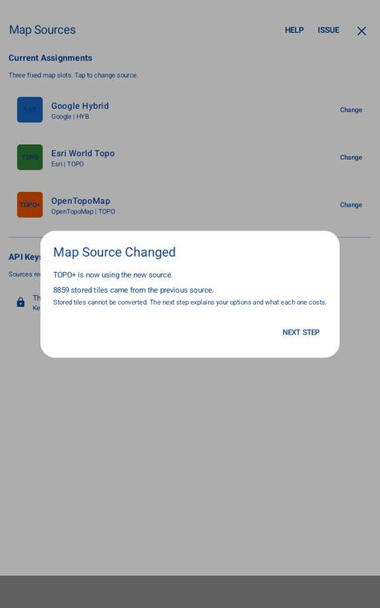

Change map source screen 3

[figure not shown]

Change map source screen 4

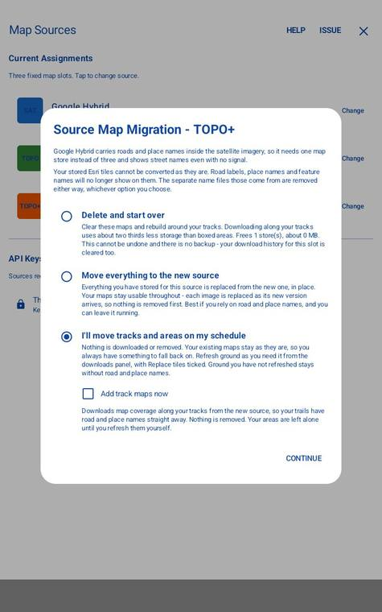

Change map source screen 5

[figure not shown]

Map source change final screen

What does it mean to me?

Two ways to reach the map sources.

**Check a trail**

What is it?

Finds out why a trail does, or does not, show on the map.

How do I use it?

First open the map on the spot where the trail should be. Then Settings › **Check a trail**: type the trail's Agency Id (from its detail panel on a tablet that shows it), its Id, or part of its name, and tap **CHECK**. Read the result; **SEND** emails it to us.

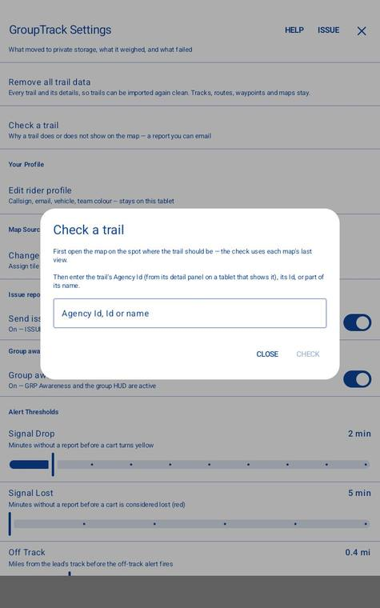

Check a trail

What does it mean to me?

A trail you know is there but cannot see gets an answer — or a report we can fix.

**Edit rider profile**

What is it?

The same screen as MENU › Account.

How do I use it?

See Account.

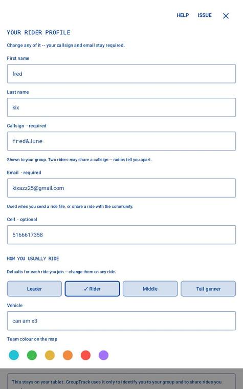

Your rider profile

What does it mean to me?

Two ways to reach your profile.

**Remove all trail data**

What is it?

Deletes every trail on this tablet — state trails and rider trails — and their details, so trails can be imported again cleanly.

How do I use it?

Settings › **Remove all trail data** › **REMOVE** (or CANCEL). It cannot be undone. Then load them again: Map › Import trails by state, and Map › Create trails from tracks.

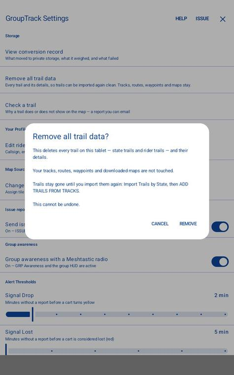

Remove all trail data

What does it mean to me?

A clean start when trails look wrong. Your tracks, routes, waypoints and downloaded maps are not touched.

**Ride statistics**

How do I use it?

Settings › **Ride statistics** (the last line). **REFRESH** updates it; **RESET** starts again (for example between two tests). To send it to us after a ride: Rides › **Email last ride statistics to GroupTrack**.

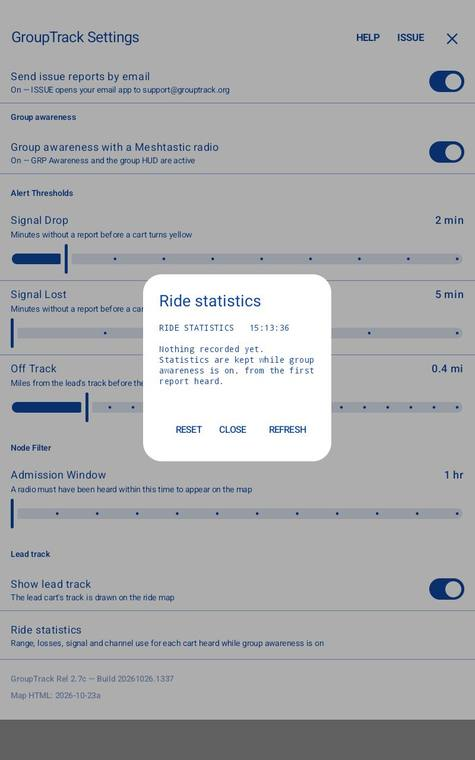

Ride statistics

What does it mean to me?

You can see how far your radios reach on your trails — and help us improve group tracking.

**View conversion record**

What is it?

The record of the one-time move of your GroupTrack files into GroupTrack's own storage: what moved, its size, and anything that failed.

How do I use it?

Settings › **View conversion record**. Read it, or tap **SHARE** to send it to us if support asks. **CLOSE** to leave.

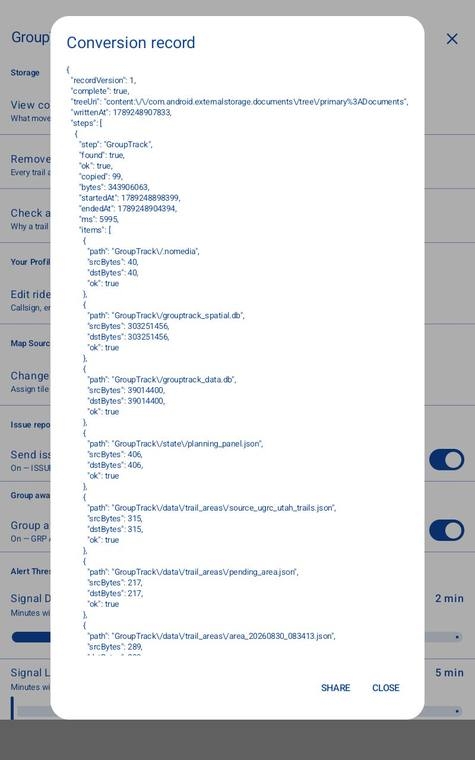

View conversion record

What does it mean to me?

If something seems missing after an update, this shows whether it was moved.

**B · Check in and recording tracks**

What is it?

The big button at the top centre runs your ride. What it shows depends on the mode:

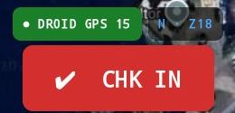

Group: CHK IN — check in first

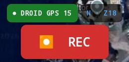

Android only: REC — record straight away

How do I use it?

- **Group:** tap **✔ CHK IN** to check in to the ride; the button then reads **⏺ REC**.
- **Android only** (or once checked in): tap **⏺ REC** to record. While recording it reads **⏸ PAUSE**; paused, it offers **RESUME** and **END**.

**Group adds one step: check in.** After that the button works exactly as it does in Android only.

What does it mean to me?

One button, always in the same place, from the trailhead to the end of the ride.